# Regression Models Project

# Appendix

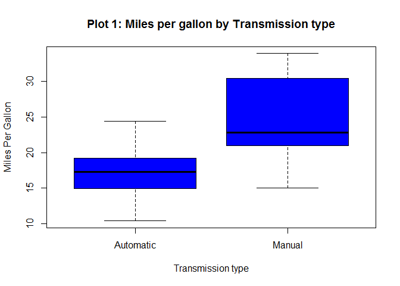

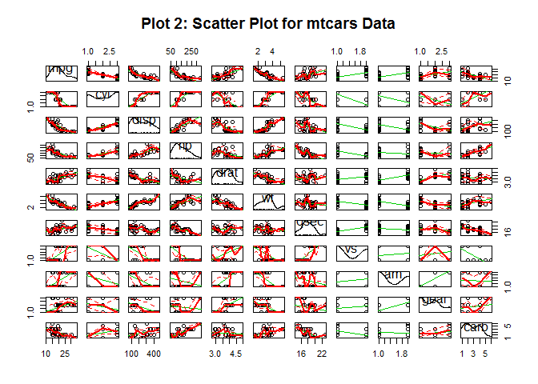

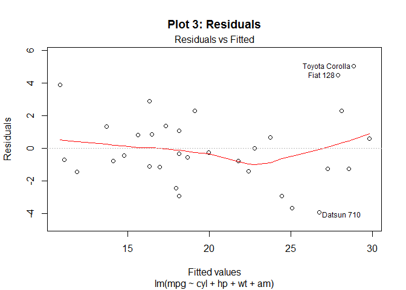

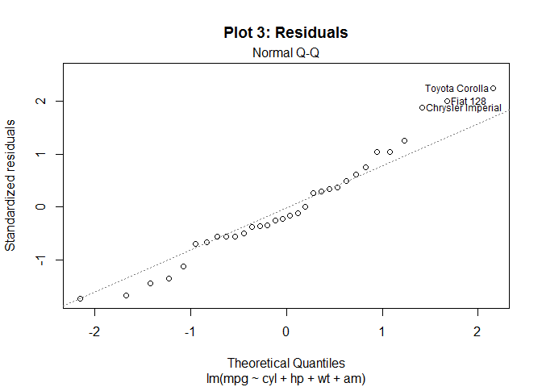

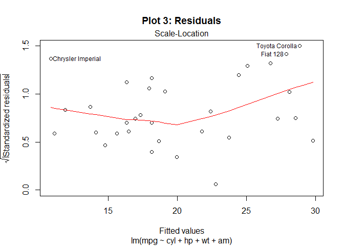

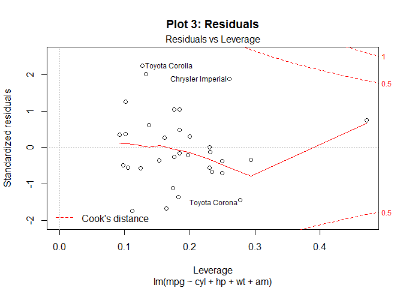

# Question

Take the mtcars data set and write up an analysis to answer their question using regression models and exploratory data analyses.

You work for Motor Trend, a magazine about the automobile industry. Looking at a data set of a collection of cars, they are interested in exploring the relationship between a set of variables and miles per gallon (MPG) (outcome). They are particularly interested in the following two questions: * “Is an automatic or manual transmission better for MPG” * “Quantify the MPG difference between automatic and manual transmissions”

# Instructions

Your report must be: * Include a first paragraph executive summary. * Brief. Roughly the equivalent of 2 pages or less for the main text. Supporting figures in an appendix can be included up to 5 total pages including the 2 for the main report. The appendix can only include figures. * Written as a PDF printout of a compiled (using knitr) R markdown document.

## Peer Grading Criteria

- Did the report include an executive summary?
- Did the student do some exploratory data analyses?
- Did the student fit multiple models and detail their strategy for model selection?
- Did the student do a residual plot and some diagnostics?
- Did the student interpret the coefficients correctly?
- Did the student quantify the uncertainty in their conclusions and/or perform an inference correctly?
- Did the student answer the questions of interest or detail why the question(s) is (are) not answerable?